# Logistic Regression Classification

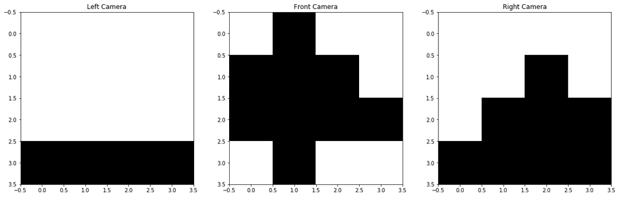

```python
%matplotlib inline
from random import choice;
from IPython.core.display import display, HTML
from __future__ import division
import math;
import numpy as np
import matplotlib.pyplot as plt
import random
import copy

plain =  [0.0, 0.0, 0.0, 0.0,0.0, 0.0, 0.0, 0.0,0.0, 0.0, 0.0, 0.0,1.0, 1.0, 1.0, 1.0]
forest = [0.0, 1.0, 0.0, 0.0,1.0, 1.0, 1.0, 0.0,1.0, 1.0, 1.0, 1.0,0.0, 1.0, 0.0, 0.0]
hills =  [0.0, 0.0, 0.0, 0.0,0.0, 0.0, 1.0, 0.0,0.0, 1.0, 1.0, 1.0,1.0, 1.0, 1.0, 1.0]
swamp =  [0.0, 0.0, 0.0, 0.0,0.0, 0.0, 0.0, 0.0,1.0, 0.0, 1.0, 0.0,1.0, 1.0, 1.0, 1.0]

figure = plt.figure(figsize=(20,6))

axes = figure.add_subplot(1, 3, 1)
pixels = np.array([255 - p * 255 for p in plain], dtype='uint8')
pixels = pixels.reshape((4, 4))
axes.set_title( "Left Camera")
axes.imshow(pixels, cmap='gray')

axes = figure.add_subplot(1, 3, 2)
pixels = np.array([255 - p * 255 for p in forest], dtype='uint8')
pixels = pixels.reshape((4, 4))
axes.set_title( "Front Camera")
axes.imshow(pixels, cmap='gray')

axes = figure.add_subplot(1, 3, 3)
pixels = np.array([255 - p * 255 for p in hills], dtype='uint8')
pixels = pixels.reshape((4, 4))
axes.set_title( "Right Camera")
axes.imshow(pixels, cmap='gray')

plt.show()
plt.close()
```

## Data

We have clean examples of the different types of terrain but based on the location, the registration can be a bit off for some of the types and the visual sensor is often blurry.

Here are the clean examples with different registrations:

```python
clean_data = {
    "plains": [
        [0.0, 0.0, 0.0, 0.0, 0.0, 0.0, 0.0, 0.0, 0.0, 0.0, 0.0, 0.0, 1.0, 1.0, 1.0, 1.0, "plains"]
    ],
    "forest": [
        [0.0, 1.0, 0.0, 0.0, 1.0, 1.0, 1.0, 0.0, 1.0, 1.0, 1.0, 1.0, 0.0, 1.0, 0.0, 0.0, "forest"],
        [0.0, 0.0, 1.0, 0.0, 0.0, 1.0, 1.0, 1.0, 1.0, 1.0, 1.0, 1.0, 0.0, 0.0, 1.0, 0.0, "forest"],
        [1.0, 0.0, 0.0, 0.0, 1.0, 1.0, 0.0, 0.0, 1.0, 1.0, 1.0, 0.0, 1.0, 0.0, 0.0, 0.0, "forest"],
        [0.0, 0.0, 0.0, 1.0, 0.0, 0.0, 1.0, 1.0, 0.0, 1.0, 1.0, 1.0, 0.0, 0.0, 0.0, 1.0, "forest"]
    ],
    "hills": [
        [0.0, 0.0, 0.0, 0.0, 0.0, 0.0, 1.0, 0.0, 0.0, 1.0, 1.0, 1.0, 1.0, 1.0, 1.0, 1.0, "hills"],
        [0.0, 0.0, 0.0, 0.0, 0.0, 1.0, 0.0, 0.0, 1.0, 1.0, 1.0, 0.0, 1.0, 1.0, 1.0, 1.0, "hills"],
        [0.0, 0.0, 0.0, 0.0, 1.0, 0.0, 0.0, 0.0, 1.0, 1.0, 0.0, 0.0, 1.0, 1.0, 1.0, 0.0, "hills"],
        [0.0, 0.0, 0.0, 0.0, 0.0, 0.0, 0.0, 1.0, 0.0, 0.0, 1.0, 1.0, 0.0, 1.0, 1.0, 1.0, "hills"]
    ],
    "swamp": [
        [0.0, 0.0, 0.0, 0.0, 0.0, 0.0, 0.0, 0.0, 1.0, 0.0, 1.0, 0.0, 1.0, 1.0, 1.0, 1.0, "swamp"],
        [0.0, 0.0, 0.0, 0.0, 0.0, 0.0, 0.0, 0.0, 0.0, 1.0, 0.0, 1.0, 1.0, 1.0, 1.0, 1.0, "swamp"]
    ]
}
```

Let's create a function that allows us to view any of these:

```python
def view_sensor_image( data):
    figure = plt.figure(figsize=(4,4))
    axes = figure.add_subplot(1, 1, 1)
    pixels = np.array([255 - p * 255 for p in data[:-1]], dtype='uint8')
    pixels = pixels.reshape((4, 4))
    axes.set_title( "Left Camera:" + data[-1])
    axes.imshow(pixels, cmap='gray')
    plt.show()
    plt.close()
```

"I think that I shall never see a thing so lovely as a tree."

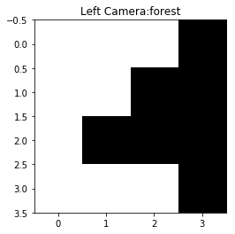

```python
view_sensor_image( clean_data[ "forest"][3])
```

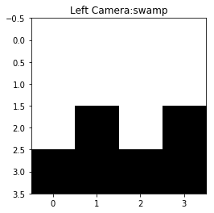

```python
view_sensor_image( clean_data["swamp"][1])
```

The data that comes in, however, is noisy. The values are never exactly 0 and 1. In order to mimic this we need a `blur` function.

We will assume that noise is normally distributed. For values that should be 0, the noisy values are distributed $N(0.10, 0.05)$. For values should be 1, the noisy values are distributed $N(0.9, 0.10)$.

```python
def blur( data):
    def apply_noise( value):
        if value < 0.5:
            v = random.gauss( 0.10, 0.05)
            if v < 0.0:
                return 0.0
            if v > 0.75:
                return 0.75
            return v
        else:
            v = random.gauss( 0.90, 0.10)
            if v < 0.25:
                return 0.25
            if v > 1.00:
                return 1.00
            return v
    noisy_readings = [apply_noise( v) for v in data[0:-1]]
    return noisy_readings + [data[-1]]
```

We can see how this affects what the agent *actually* sees.

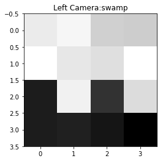

```python
view_sensor_image( blur( clean_data["swamp"][0]))
```

## Helper Functions

*get_y_hat*

This function calculates the y_hat value where y_hat = 1/[1+e^(-theta·x)].

```python
def get_y_hat(thetas, element):
    term = 0;
    for i in range(len(thetas)):
        theta = thetas[i];
        x = element[i];
        term += x*theta;
    term = math.exp(-1*term);
    denominator = 1 + term;

    y_hat = 1/denominator;
    return y_hat;
```

*calculate_error*

This function calculates error where log loss = -1/n · ε [y · log(y_hat) + (1-y)·log(1-y_hat)]

```python
def calculate_error(thetas, data):
    n = len(data);
    J = 0;

    for i in range(len(thetas)):
        y = data[i][17];
        y_hat = get_y_hat(thetas, data[i]);
        J += y*math.log(y_hat) + (1-y)*math.log(1-y_hat);

    J *= -1/n;
    return J;
```

*derivative*

This function calculates the derivative where derivative = 1/n · ε [(y_hat – y) · x]

```python
def derivative(j, thetas, data):
    derivative = 0;
    n = len(data);

    for i in range(len(thetas)):
        y = data[i][17];
        y_hat = get_y_hat(thetas, data[i]);
        x = data[i][j];
        derivative += (y_hat - y)*x;

    derivative *= 1.0/n;
    return derivative;
```

## Main Functions

### `generate_data`

This function generates blurred hills and not hills examples. It transforms string labels into binary 0 or 1.

```python
def generate_data(data, n, label):
    new_data = [];

    for i in range(n):
        count1 = len(data[label]) - 1;
        thisIndex1 = random.randint(0, count1);
        thisElement1 = blur(data[label][thisIndex1]);
        thisElement1[16] = 1;
        thisElement1.insert(0,1.0);
        new_data.append(thisElement1);

        random_list = choice(list(data.values()));
        while(random_list[0][16] == label):
            random_list = choice(list(data.values()));
        count0 = len(random_list) - 1;
        thisIndex0 = random.randint(0, count0);
        thisElement0 = blur(random_list[thisIndex0]);
        thisElement0[16] = 0;
        thisElement0.insert(0,1.0);
        new_data.append(thisElement0);
    return new_data;

results = generate_data(clean_data, 10, "hills")
for result in results:
    print result
```

```
[1.0, 0.09156980872280254, 0.05185049722104037, 0.09944238362654681, 0.11415365662472236, 0.15739507241404224, 0.08470003521115721, 0.16862167874701223, 0.9628029605018803, 0.10393694948978043, 0.053688447268338935, 0.9874304103952712, 0.8315869554850478, 0.10827861421586732, 0.6792425429128404, 1.0…
[1.0, 0.13266306010687398, 0.06812223622544973, 0.13882777509995614, 0.12429998942557206, 0.21256652899610112, 0.08566811407868467, 0.09159289930269873, 0.13404934037680544, 0.148863892201192, 0.9894460489039462, 0.11401769663608416, 0.8294080860986056, 0.8780916001009134, 0.821436258044599, 0.83769…
[1.0, 0.07315894519316589, 0.09099999537189987, 0.16434902671235785, 0.04601931061374207, 0.11941260501435105, 0.04488524094820885, 0.13319889913011312, 0.8719242648904633, 0.010576079622860987, 0.07359248094751468, 0.9882814981409653, 1.0, 0.09976550265683769, 0.9495348953036762, 0.8762030895220936…
[1.0, 0.13249596619884066, 0.12887618048280916, 0.18125382537958679, 0.11096483620585623, 0.1147535808684438, 0.14949185323680883, 0.05545400053577081, 0.018229414631518517, 0.12920098965178822, 0.790225625540588, 0.048364597209068896, 0.8529400339389912, 0.8486641328023792, 0.8368125449410924, 0.83…
[1.0, 0.13213148559483967, 0.0023912199702122716, 0.03412059697143485, 0.02400944803638308, 0.0738935067351538, 0.09314413521943055, 0.0498175805322835, 0.9128776866787403, 0.10143309548863551, 0.09056021277237374, 0.9526355639541024, 0.7931731413653945, 0.11766168753461206, 0.9742943028850117, 0.87…
[1.0, 0.017518135727320125, 0.9590131102267035, 0.16712718631380766, 0.10777136683800852, 0.8674568247910561, 0.7446070533836873, 1.0, 0.11906495530647024, 1.0, 0.8824094069306587, 0.7777196906156804, 1.0, 0.15964491577587062, 0.7748741166996549, 0.08082389940702403, 0.09630930846461593, 0]
[1.0, 0.14037052184497376, 0.0734031583950202, 0.1613958661236001, 0.1695959527307916, 0.08946882389672507, 0.11623030800523595, 0.8364557234992838, 0.060383050693021086, 0.03592225129198012, 0.747149220639342, 0.904460406952354, 0.9299753636626056, 0.8347212831356893, 0.9717098609265946, 0.85699044…
[1.0, 0.07085204849729476, 0.12340938819998072, 0.10682018721781511, 0.16475284775433613, 0.11516014672971736, 0.06005624250624125, 0.03317539259170767, 0.20916371584904114, 0.018709449954927723, 0.8421935193664598, 0.10844808082909958, 0.8798549520709065, 0.8458155852860916, 0.7197034676831685, 1.0…
[1.0, 0.04965829359085029, 0.10270509951064608, 0.1052786355374104, 0.14019327115436786, 0.017995849305234984, 0.167079474189115, 0.8497088532521223, 0.13558113541957403, 0.14381933871383057, 1.0, 0.7566689992190396, 0.9183418307278534, 0.9002010786693325, 0.9403393533034861, 0.8933706857327753, 0.7…
[1.0, 0.11539356618164776, 0.04772643898028848, 0.14000703747210255, 0.10990009504832973, 0.10954157065425787, 0.02542211851143722, 0.10674080844553696, 0.10535453009650694, 0.030630033459986994, 0.974778398766154, 0.08140340789287062, 0.9107073748191981, 0.8876136137494122, 1.0, 0.6592177184101097,…
[1.0, 0.06177838122897666, 0.09316359016485967, 0.09081116862461917, 0.17889231689458304, 0.15271846469812572, 0.18886670315020862, 1.0, 0.11549587518713218, 0.04000860573627496, 0.7441289553666356, 0.7346483510105821, 0.7029491863853787, 0.806085875191862, 0.9290134109953821, 0.8030099923407399, 0.…
[1.0, 0.09917582014272079, 0.0, 0.18072574454147056, 0.08068569538786582, 0.09347319590849947, 0.11850528088810004, 0.02535446727829442, 0.09605197488497082, 0.14688323591110025, 0.8127499626064403, 0.10415189064959526, 1.0, 0.8639536040806208, 0.9474119995294084, 0.8904393909178918, 0.9072678881152…
[1.0, 0.0004043062297434119, 0.11345473562327599, 0.07043621981067566, 0.0758827480029874, 0.05849926341997177, 0.10484012213466957, 0.8748779748208086, 0.19018351023954652, 0.10314809441548596, 0.7719860686274764, 0.6628445356533454, 1.0, 0.9933005580285952, 0.9147238788416938, 0.8921020371436444, …
[1.0, 0.1818540817293588, 0.04804755999442589, 0.07117985814634743, 0.020882867759801443, 0.1272052044806288, 0.08404219023182112, 0.0602383626338981, 0.043046274891154514, 0.13247947749479963, 0.08187142038808631, 0.0, 0.08439809537396747, 0.9086884493185602, 1.0, 0.8326534417046959, 0.871426120449…
[1.0, 0.12359628147117914, 0.09909946767795574, 0.11941956940229288, 0.07949969259991618, 1.0, 0.015618154321375949, 0.12735261537494222, 0.051117669330037606, 0.802009470972928, 0.9234792391880419, 0.17786191158929515, 0.09583227516386289, 1.0, 0.9858912707629153, 0.8214250863275037, 0.186315591374…
[1.0, 0.8443818030077574, 0.17236993243961624, 0.16357383717728002, 0.09521256709805001, 0.8890944895721218, 1.0, 0.09465023152004153, 0.05381137979942288, 0.9998892694916606, 1.0, 0.8617517960095324, 0.07613789522647504, 0.8761994174305688, 0.1250740582661165, 0.02206222206368444, 0.032831055924160…
[1.0, 0.09476748106667938, 0.15901791879303323, 0.0, 0.04279303201554863, 0.06128587485402953, 0.8150083216300342, 0.13053236592202622, 0.23354687073079347, 1.0, 1.0, 0.8544890777117045, 0.09065943676250503, 0.6841842319545117, 0.9820348051253323, 0.7417537261151681, 1.0, 1]
[1.0, 0.09334601424239383, 0.03758210446089703, 0.16070140558477897, 0.9236365854584878, 0.09051755293772265, 0.1358284406112926, 0.9316087220452898, 0.916150668794904, 0.13993561492102546, 0.9686833533789915, 0.8562940717773788, 0.9749623990106221, 0.16411823932737613, 0.22144736481088897, 0.095503…
[1.0, 0.06175093585902977, 0.08123205931282294, 0.033462825788502334, 0.0951946692209461, 0.8561115240508884, 0.10207153986115516, 0.15453235200294893, 0.0, 0.9481385819606041, 0.9230502395935734, 0.06725519689455997, 0.12929009488430843, 0.9971030875236062, 1.0, 0.7105169946867467, 0.12267029035986…
[1.0, 0.025385580993244325, 0.0702712809929941, 0.10393234715167832, 0.11746483536097066, 0.09227598262087694, 0.12205588905244197, 0.12292649871874253, 0.16491129120189563, 0.11299711014520869, 0.18328268951011173, 0.18936724953202555, 0.041681336971436334, 0.9578493636617443, 0.7351162495186778, 0…
```

### `learn_model`

`learn_model` is the function that takes in training data and learns the logistic regression model with the gradient descent approach. When verbose is True, the error is printed out every 1,000 iterations. Returns the List of Thetas.

```python
def learn_model(data, verbose):
    epsilon = 0.0000001;
    alpha = 0.1;

    thetas = [];
    for i in range(17):
        thetas.append(random.uniform(-1, 1));
    previous_error = 0.0;
    current_error = calculate_error(thetas, data);

    iteration = 0;
    while abs(current_error - previous_error) >= epsilon:
        new_thetas = [];
        for j in range(len(thetas)):
            new_theta = thetas[j] - (alpha * derivative(j, thetas, data));
            new_thetas.append(new_theta);
        thetas = new_thetas;
        previous_error = current_error;
        current_error = calculate_error(thetas, data);
        iteration += 1;
        if verbose and (iteration % 1000 == 0):
            print "Iteration #", iteration, "with error", current_error;
    return thetas;

train_data = generate_data(clean_data, 100, "hills")
model = learn_model(train_data, True)
print model
```

```
Iteration # 1000 with error 0.0442788382441
Iteration # 2000 with error 0.0365052434953
Iteration # 3000 with error 0.0314116259459
Iteration # 4000 with error 0.0276438285497
Iteration # 5000 with error 0.0246930492032
Iteration # 6000 with error 0.0223001179548
Iteration # 7000 with error 0.020311214591
Iteration # 8000 with error 0.0186277915649
Iteration # 9000 with error 0.0171830958869
Iteration # 10000 with error 0.0159297135602
Iteration # 11000 with error 0.0148326146283
Iteration # 12000 with error 0.013865096307
Iteration # 13000 with error 0.0130063016918
Iteration # 14000 with error 0.0122396275877
Iteration # 15000 with error 0.0115516564829
Iteration # 16000 with error 0.0109314119544
Iteration # 17000 with error 0.0103698226051
Iteration # 18000 with error 0.00985932587311
Iteration # 19000 with error 0.00939356892361
Iteration # 20000 with error 0.0089671788863
Iteration # 21000 with error 0.00857558381805
Iteration # 22000 with error 0.00821487150772
Iteration # 23000 with error 0.00788167697653
Iteration # 24000 with error 0.00757309203897
Iteration # 25000 with error 0.00728659202226
Iteration # 26000 with error 0.00701997596745
Iteration # 27000 with error 0.00677131751707
Iteration # 28000 with error 0.00653892434104
Iteration # 29000 with error 0.00632130443292
Iteration # 30000 with error 0.00611713797046
Iteration # 31000 with error 0.00592525370935
Iteration # 32000 with error 0.00574460909086
Iteration # 33000 with error 0.00557427340776
Iteration # 34000 with error 0.00541341350064
Iteration # 35000 with error 0.00526128155793
Iteration # 36000 with error 0.00511720467178
Iteration # 37000 with error 0.00498057586618
Iteration # 38000 with error 0.00485084636379
Iteration # 39000 with error 0.00472751889916
Iteration # 40000 with error 0.00461014191913
Iteration # 41000 with error 0.00449830453755
Iteration # 42000 with error 0.00439163213413
[-3.3071137092953506, 0.04119949798286588, -5.755877343215049, -1.3121354675155819, -0.24801036676240307, -0.7757901320664825, -1.8449995092467, 0.16238651071003504, 2.9178658609591333, 2.0602380980671855, 2.0973817908508328, 6.408605487318302, -0.2997410863759345, 0.2029594315914667, -0.63924994938…
```

```
First 10 Results:

1 )  [1.0, 0.0868373315058433, 0.1347931111144448, 0.12400889776589596, 0.1742276508676454, 0.08625781856258394, 0.9644576503724993, 0.0, 0.10737741505176888, 0.8445718571051332, 0.9593435467888475, 0.9119478356838161, 0.1673056270816377, 1.0, 0.8449852480284458, 0.9225985298978234, 0.94238287298258…
```

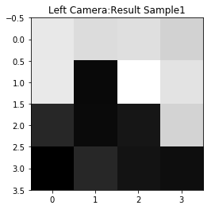

```
2 )  [1.0, 0.13249546826572875, 0.06998582597607668, 0.12571363698355922, 0.00416864406468509, 0.015565220732824847, 0.10943468737170609, 0.04132257219287695, 0.0863954024518534, 0.17296769193437922, 0.049120901312070586, 0.07532035822148471, 0.1615393265847537, 0.7949864354962657, 0.795743370945162…
```

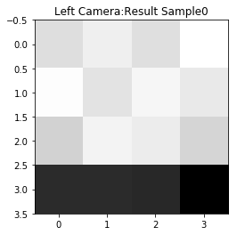

```
3 )  [1.0, 0.09003654547453258, 0.07657224181992751, 0.09313522862679736, 0.13234772115741827, 0.04486209024383589, 0.07728295377588931, 0.08679455501800204, 0.9904664830903068, 0.10592774375401727, 0.11758044171812021, 1.0, 0.9409798173889405, 0.08065620727344726, 0.731398528734345, 0.9160154418269…
```

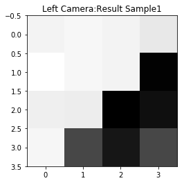

```
4 )  [1.0, 0.08715191722672982, 0.988248953513806, 0.10921641444653149, 0.13241884351657632, 1.0, 0.851998446119361, 0.8340702317003612, 0.10727803137884367, 0.8826375297970844, 1.0, 0.9558415419140286, 0.8586996911507729, 0.11712379770606704, 0.9800297749862049, 0.0012046816629409235, 0.06558886569…
```

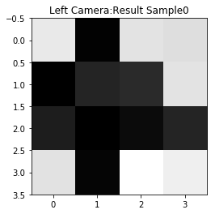

```
5 )  [1.0, 0.04330546305878019, 0.06548843829714882, 0.1905718431729032, 0.08527409473982267, 0.12414011502801232, 0.10801233067098283, 0.14359912531482705, 0.9674287996139994, 0.09501621375504418, 0.07364260557464428, 0.9537202370938875, 0.9524105881871379, 0.09622398277984527, 0.8813293495863564, …
```

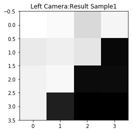

```
6 )  [1.0, 0.04534362280678409, 0.06225759378708279, 0.19346140375089713, 0.06325797877624112, 0.0697963271765514, 0.05172281556145127, 0.15122984902122344, 0.17601690831640876, 0.11239742887234568, 1.0, 0.026721009686650823, 0.9349768181008652, 0.7799943277662742, 0.8727438251556413, 0.951398188493…
```

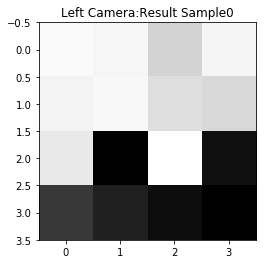

```
7 )  [1.0, 0.14982467719518971, 0.2096704404385501, 0.06280976634052665, 0.16970922878111916, 0.0502780730346605, 0.7934638893675381, 0.026635086533302363, 0.20682452989073552, 0.9625613783348786, 1.0, 1.0, 0.08722073345359219, 0.9612717254345349, 0.83592949627644, 0.9508802992533039, 0.770007712099…
```

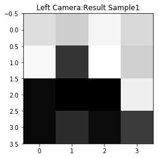

```
8 )  [1.0, 0.10941003002164591, 0.10530552378021119, 0.05224803550868368, 0.008073230304340734, 0.08471739092480013, 0.07385431811223359, 0.13483205100314222, 0.01540362135521331, 0.16514044954686424, 0.0974756223817691, 0.11505090736007352, 0.15215655747076456, 0.9058372495471642, 0.664606256873944…
```

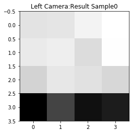

```
9 )  [1.0, 0.11250939118654615, 0.08441122360307941, 0.06106297826005552, 0.05773795252455862, 0.11969324592673308, 0.745588189225404, 0.13436843967713102, 0.11276819747783062, 0.8441435129066812, 0.8539675211405229, 0.9246067577593309, 0.09581069139544655, 0.9174538630271429, 0.8981422853069715, 0.…
```

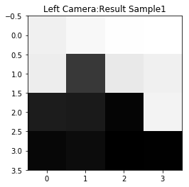

```
10 )  [1.0, 0.07897947582699488, 0.10635440078565285, 0.08047271849741608, 0.13151916265100602, 0.1498351735035286, 0.06926631823513074, 0.12616176585439304, 0.12196567051179316, 0.05290104653631296, 0.10915273286013769, 0.05303948265674868, 0.1962268970715869, 0.8589278053902578, 0.8996285901871883…
```

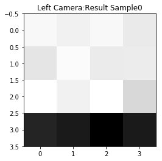

```python
print "\nFirst 10 Results:\n"

for i in range(10):
    print i+1, ') ', train_data[i], '\n';
    this_result = copy.copy(train_data[i]);
    del this_result[0];
    this_result[-1] = "Result Sample" + str(this_result[-1]);
    view_sensor_image(this_result);
```

### `apply_model`

This function takes a List of Thetas (the model) and either labeled or unlabeled data. If the data is unlabeled, it returns predictions for each observation as a Tuple of the inferred value (0 or 1) and the actual probability (so something like (1, 0.73) or (0, 0.19). If the data is labeled, it returns a Tuple of the actual value (0 or 1) and the predicted value (0 or 1).

```python
test_data = generate_data( clean_data, 100, "hills")

def apply_model( model, test_data, labeled=False):
    answer = [];

    if labeled:
        for element in test_data:
            actual_value = element[17];
            actual_probability = get_y_hat(model, element);
            if actual_probability > 0.5:
                inferred_value = 1;
            else:
                inferred_value = 0;
            answer.append((actual_value, inferred_value));
    else:
        for element in test_data:
            actual_probability = get_y_hat(model, element);
            if actual_probability > 0.5:
                inferred_value = 1;
            else:
                inferred_value = 0;
            answer.append((inferred_value, actual_probability));
    return answer;

results = apply_model( model, test_data)
print results
```

```
[(1, 0.9738454674550305), (0, 0.04152108714119811), (1, 0.9869512173140538), (0, 0.03559826382545605), (1, 0.9758140568286141), (1, 0.9631973820782733), (1, 0.7719323655538999), (0, 0.10477008432859763), (1, 0.9189976023511878), (0, 0.021236527583985195), (1, 0.9204826835490868), (0, 0.3332604302390…
```

Using the results above, show your confusion matrix for your model.

### `calculate_confusion_matrix`

The `calculate_confusion_matrix` takes the results of `apply_model` when labeled=True and prints a nice HTML version of a confusion matrix and include statistics for error rate, true positive rate and true negative rate.

```python
results = apply_model( model, test_data, True)

def calculate_confusion_matrix(results):
    (tp, fn, fp, tn) = (0, 0, 0, 0);
    n = len(results);

    for result in results:
        (a, b) = result;
        if a:
            if b: tp += 1;
            else: fp += 1;
        else:
            if b: fn += 1;
            else: tn += 1;

    htmlString = '<h1>Confusion Matrix</h1><table>';
    htmlString += '<tr><th></th><th>Predicted Condition Positive</th><th>Predicted Condition Negative</th></tr>';
    htmlString += '<tr><th>Actual Condition Positive</th>';
    htmlString += '<td style="background-color:aquamarine; text-align: center">True Positive (TP): <br />';
    htmlString += str(tp) +'/'+ str(n) + ' = ' + str(tp/n*100) + '%</td>';
    htmlString += '<td style="background-color:pink; text-align: center">False Negative (FN): <br />';
    htmlString += str(fn) +'/'+ str(n) + ' = ' + str(fn/n*100) + '%</td></tr>';
    htmlString += '<tr><th>Actual Condition Negative</th>';
    htmlString += '<td style="background-color:pink; text-align: center">False Positive (FP): <br />';
    htmlString += str(fp) +'/'+ str(n) + ' = ' + str(fp/n*100) + '%</td>';
    htmlString += '<td style="background-color:aquamarine; text-align: center">True Negative (TN): <br />';
    htmlString += str(tn) +'/'+ str(n) + ' = ' + str(tn/n*100) + '%</td></tr>';
    htmlString += '</table>';
    htmlString += '<h2>Error rate</h2>' + str((fn+fp)/n*100) + '%';
    htmlString += '<h2>True positive rate</h2>' + str(tp/(tp+fn)*100) + '%';
    htmlString += '<h2>True negative rate</h2>' + str(tn/(tn+fp)*100) + '%';
    display(HTML(htmlString));

calculate_confusion_matrix(results);
```

Confusion Matrix

|  | Predicted Condition Positive | Predicted Condition Negative |
| --- | --- | --- |
| Actual Condition Positive | True Positive (TP): 100/200 = 50.0% | False Negative (FN): 38/200 = 19.0% |
| Actual Condition Negative | False Positive (FP): 0/200 = 0.0% | True Negative (TN): 62/200 = 31.0% |

Error rate

19.0%

True positive rate

72.4637681159%

True negative rate

100.0%